# Prosper Loan Data Exploration

## Preliminary Wrangling

> Analysis of Prosper loan data of about 113,000 records

```python
# import all packages and set plots to be embedded inline
import numpy as np
import pandas as pd
import matplotlib.pyplot as plt
import seaborn as sb

%matplotlib inline
```

```python
# Read in dataset from CSV file
df = pd.read_csv('prosperLoanData.csv')
```

```python
# Look at the dataset's basic characteristics
print(df.shape)
print(df.info())
```

```
(113937, 81)
<class 'pandas.core.frame.DataFrame'>
RangeIndex: 113937 entries, 0 to 113936
Data columns (total 81 columns):
ListingKey                             113937 non-null object
ListingNumber                          113937 non-null int64
ListingCreationDate                    113937 non-null object
CreditGrade                            28953 non-null object
Term                                   113937 non-null int64
LoanStatus                             113937 non-null object
ClosedDate                             55089 non-null object
BorrowerAPR                            113912 non-null float64
BorrowerRate                           113937 non-null float64
LenderYield                            113937 non-null float64
EstimatedEffectiveYield                84853 non-null float64
EstimatedLoss                          84853 non-null float64
EstimatedReturn                        84853 non-null float64
ProsperRating (numeric)                84853 non-null float64
ProsperRating (Alpha)                  84853 non-null object
ProsperScore                           84853 non-null float64
ListingCategory (numeric)              113937 non-null int64
BorrowerState                          108422 non-null object
Occupation                             110349 non-null object
EmploymentStatus                       111682 non-null object
EmploymentStatusDuration               106312 non-null float64
IsBorrowerHomeowner                    113937 non-null bool
CurrentlyInGroup                       113937 non-null bool
GroupKey                               13341 non-null object
DateCreditPulled                       113937 non-null object
CreditScoreRangeLower                  113346 non-null float64
CreditScoreRangeUpper                  113346 non-null float64
FirstRecordedCreditLine                113240 non-null object
CurrentCreditLines                     106333 non-null float64
OpenCreditLines                        106333 non-null float64
TotalCreditLinespast7years             113240 non-null float64
OpenRevolvingAccounts                  113937 non-null int64
OpenRevolvingMonthlyPayment            113937 non-null float64
InquiriesLast6Months                   113240 non-null float64
TotalInquiries                         112778 non-null float64
CurrentDelinquencies                   113240 non-null float64
```

[output cut: 33 more lines]

```
LP_CustomerPrincipalPayments           113937 non-null float64
LP_InterestandFees                     113937 non-null float64
LP_ServiceFees                         113937 non-null float64
LP_CollectionFees                      113937 non-null float64
LP_GrossPrincipalLoss                  113937 non-null float64
LP_NetPrincipalLoss                    113937 non-null float64
LP_NonPrincipalRecoverypayments        113937 non-null float64
PercentFunded                          113937 non-null float64
Recommendations                        113937 non-null int64
InvestmentFromFriendsCount             113937 non-null int64
InvestmentFromFriendsAmount            113937 non-null float64
Investors                              113937 non-null int64
dtypes: bool(3), float64(50), int64(11), object(17)
memory usage: 68.1+ MB
None
```

```python
# Look at the top 10 records from the dataframe
df.head(10)
```

|  | ListingKey | ListingNumber | ListingCreationDate | CreditGrade | Term | LoanStatus | ClosedDate | BorrowerAPR | BorrowerRate | LenderYield | ... | LP_ServiceFees | LP_CollectionFees | LP_GrossPrincipalLoss | LP_NetPrincipalLoss | LP_NonPrincipalRecoverypayments | PercentFunded | Recommendations | InvestmentFromFriendsCount | InvestmentFromFriendsAmount | Investors |
| --- | --- | --- | --- | --- | --- | --- | --- | --- | --- | --- | --- | --- | --- | --- | --- | --- | --- | --- | --- | --- | --- |
| 0 | 1021339766868145413AB3B | 193129 | 2007-08-26 19:09:29.263000000 | C | 36 | Completed | 2009-08-14 00:00:00 | 0.16516 | 0.1580 | 0.1380 | ... | -133.18 | 0.0 | 0.0 | 0.0 | 0.0 | 1.0 | 0 | 0 | 0.0 | 258 |
| 1 | 10273602499503308B223C1 | 1209647 | 2014-02-27 08:28:07.900000000 | NaN | 36 | Current | NaN | 0.12016 | 0.0920 | 0.0820 | ... | 0.00 | 0.0 | 0.0 | 0.0 | 0.0 | 1.0 | 0 | 0 | 0.0 | 1 |
| 2 | 0EE9337825851032864889A | 81716 | 2007-01-05 15:00:47.090000000 | HR | 36 | Completed | 2009-12-17 00:00:00 | 0.28269 | 0.2750 | 0.2400 | ... | -24.20 | 0.0 | 0.0 | 0.0 | 0.0 | 1.0 | 0 | 0 | 0.0 | 41 |
| 3 | 0EF5356002482715299901A | 658116 | 2012-10-22 11:02:35.010000000 | NaN | 36 | Current | NaN | 0.12528 | 0.0974 | 0.0874 | ... | -108.01 | 0.0 | 0.0 | 0.0 | 0.0 | 1.0 | 0 | 0 | 0.0 | 158 |
| 4 | 0F023589499656230C5E3E2 | 909464 | 2013-09-14 18:38:39.097000000 | NaN | 36 | Current | NaN | 0.24614 | 0.2085 | 0.1985 | ... | -60.27 | 0.0 | 0.0 | 0.0 | 0.0 | 1.0 | 0 | 0 | 0.0 | 20 |
| 5 | 0F05359734824199381F61D | 1074836 | 2013-12-14 08:26:37.093000000 | NaN | 60 | Current | NaN | 0.15425 | 0.1314 | 0.1214 | ... | -25.33 | 0.0 | 0.0 | 0.0 | 0.0 | 1.0 | 0 | 0 | 0.0 | 1 |
| 6 | 0F0A3576754255009D63151 | 750899 | 2013-04-12 09:52:56.147000000 | NaN | 36 | Current | NaN | 0.31032 | 0.2712 | 0.2612 | ... | -22.95 | 0.0 | 0.0 | 0.0 | 0.0 | 1.0 | 0 | 0 | 0.0 | 1 |
| 7 | 0F1035772717087366F9EA7 | 768193 | 2013-05-05 06:49:27.493000000 | NaN | 36 | Current | NaN | 0.23939 | 0.2019 | 0.1919 | ... | -69.21 | 0.0 | 0.0 | 0.0 | 0.0 | 1.0 | 0 | 0 | 0.0 | 1 |
| 8 | 0F043596202561788EA13D5 | 1023355 | 2013-12-02 10:43:39.117000000 | NaN | 36 | Current | NaN | 0.07620 | 0.0629 | 0.0529 | ... | -16.77 | 0.0 | 0.0 | 0.0 | 0.0 | 1.0 | 0 | 0 | 0.0 | 1 |
| 9 | 0F043596202561788EA13D5 | 1023355 | 2013-12-02 10:43:39.117000000 | NaN | 36 | Current | NaN | 0.07620 | 0.0629 | 0.0529 | ... | -16.77 | 0.0 | 0.0 | 0.0 | 0.0 | 1.0 | 0 | 0 | 0.0 | 1 |

10 rows × 81 columns

### What is the structure of your dataset?

> The dataset consists of 113,937 loans (rows) from Prosper. There are 81 variables (columns) in the entire dataset. A variable dictionary is provided at this [GoogleDoc](https://docs.google.com/spreadsheets/d/1gDyi_L4UvIrLTEC6Wri5nbaMmkGmLQBk-Yx3z0XDEtI/edit#gid=0). I will focus on a subset of those variables.

```
                (worst) ---> (best)
```

The `CreditGrade` scale: NC, HR, E, D, C, B, A, AA

The `ProsperRating (Alpha)` scale : N/A, HR, E, D, C, B, A, AA

### What is/are the main feature(s) of interest in your dataset?

> I want to know what factors determine a loan's interest rate?

### What features in the dataset do you think will help support your investigation into your feature(s) of interest?

> I think that the two columns mentioned above (CreditGrade & ProsperRating) will have a large impact on the interest rate for a loan. As well as the credit socre range and the proprietary ProsperScore risk score are likely to be highly correlated. And additionally I think that the IncomeRange and DebtToIncomeRatio will aslo be a factor in the loan's interest rate.

## Univariate Exploration

```python
# Convert CreditGrade and ProsperScore to an ordered type
ordinal_var_dict = {'CreditGrade': ['NC', 'HR', 'E', 'D', 'C', 'B', 'A', 'AA'],
                    'ProsperRating (Alpha)': ['N/A', 'HR', 'E', 'D', 'C', 'B', 'A', 'AA']}

for var in ordinal_var_dict:
    ordered_var = pd.api.types.CategoricalDtype(ordered=True, categories=ordinal_var_dict[var])
    df[var] = df[var].astype(ordered_var)
```

```python
# See what the ProsperRating values look like
df['ProsperRating (Alpha)'].value_counts()
```

```
C      18345
B      15581
A      14551
D      14274
E       9795
HR      6935
AA      5372
N/A        0
Name: ProsperRating (Alpha), dtype: int64
```

```python
# And likewise for CreditGrade
df['CreditGrade'].value_counts()
```

```
C     5649
D     5153
B     4389
AA    3509
HR    3508
A     3315
E     3289
NC     141
Name: CreditGrade, dtype: int64
```

```python
# Set the max_columns Pandas option to a higher value to
# view the entire dataset inside a Jupyter notebook
pd.set_option('display.max_columns', 100)

df[df.ListingNumber.duplicated(keep=False)][:2]
```

|  | ListingKey | ListingNumber | ListingCreationDate | CreditGrade | Term | LoanStatus | ClosedDate | BorrowerAPR | BorrowerRate | LenderYield | EstimatedEffectiveYield | EstimatedLoss | EstimatedReturn | ProsperRating (numeric) | ProsperRating (Alpha) | ProsperScore | ListingCategory (numeric) | BorrowerState | Occupation | EmploymentStatus | EmploymentStatusDuration | IsBorrowerHomeowner | CurrentlyInGroup | GroupKey | DateCreditPulled | CreditScoreRangeLower | CreditScoreRangeUpper | FirstRecordedCreditLine | CurrentCreditLines | … |
| --- | --- | --- | --- | --- | --- | --- | --- | --- | --- | --- | --- | --- | --- | --- | --- | --- | --- | --- | --- | --- | --- | --- | --- | --- | --- | --- | --- | --- | --- | --- |
| 8 | 0F043596202561788EA13D5 | 1023355 | 2013-12-02 10:43:39.117000000 | NaN | 36 | Current | NaN | 0.0762 | 0.0629 | 0.0529 | 0.05221 | 0.0099 | 0.04231 | 7.0 | AA | 9.0 | 7 | IL | Food Service | Employed | 269.0 | True | False | NaN | 2013-12-02 10:43:39 | 820.0 | 839.0 | 1993-04-01 00:00:00 | 17.0 | … |
| 9 | 0F043596202561788EA13D5 | 1023355 | 2013-12-02 10:43:39.117000000 | NaN | 36 | Current | NaN | 0.0762 | 0.0629 | 0.0529 | 0.05221 | 0.0099 | 0.04231 | 7.0 | AA | 11.0 | 7 | IL | Food Service | Employed | 269.0 | True | False | NaN | 2013-12-02 10:43:39 | 820.0 | 839.0 | 1993-04-01 00:00:00 | 17.0 | … |

```python
# Look at describe() for the interest rate columns
df[['BorrowerAPR', 'BorrowerRate']].describe()
```

|  | BorrowerAPR | BorrowerRate |
| --- | --- | --- |
| count | 113912.000000 | 113937.000000 |
| mean | 0.218828 | 0.192764 |
| std | 0.080364 | 0.074818 |
| min | 0.006530 | 0.000000 |
| 25% | 0.156290 | 0.134000 |
| 50% | 0.209760 | 0.184000 |
| 75% | 0.283810 | 0.250000 |
| max | 0.512290 | 0.497500 |

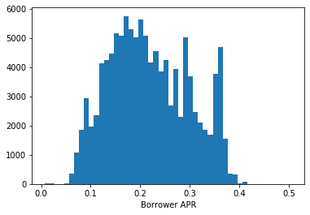

```python
# Plot the distribution of BorrowerAPR
apr_bins = np.arange(df.BorrowerAPR.min(), df.BorrowerAPR.max(), 0.01)

plt.hist(data=df, x='BorrowerAPR', bins=apr_bins);
plt.xlabel('Borrower APR');
```

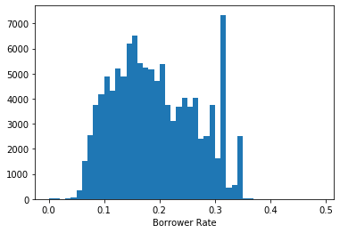

```python
# Plot the distribution of BorrowerRate
rate_bins = np.arange(df.BorrowerRate.min(), df.BorrowerRate.max(), 0.01)

plt.hist(data=df, x='BorrowerRate', bins=rate_bins)
plt.xlabel('Borrower Rate');
```

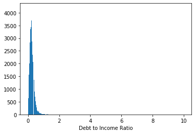

```python
# Plot the distribution of DebtToIncomeRatio
ratio_bins = np.arange(df.DebtToIncomeRatio.min(), df.DebtToIncomeRatio.max()+0.0, 0.01)

plt.hist(data=df, x='DebtToIncomeRatio', bins=ratio_bins);
plt.xlabel('Debt to Income Ratio');
```

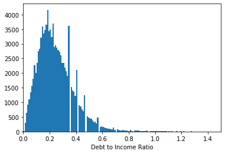

```python
# It looks like there are extreme outliers in the data ofr DebtToIncomeRatio
# Let's take a look at at data between a ratio of 0 and 1.5

plt.hist(data=df, x='DebtToIncomeRatio', bins=ratio_bins);
plt.xlim(0,1.5);
plt.xlabel('Debt to Income Ratio');
```

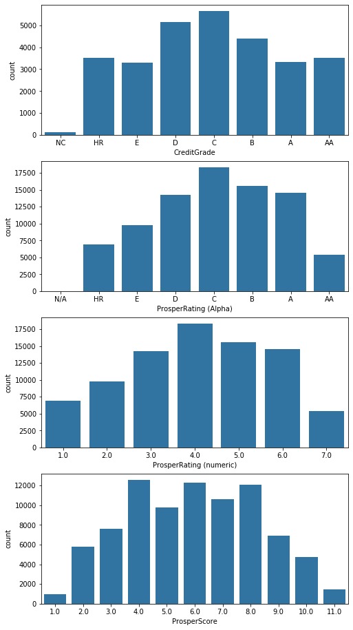

```python
# Look at the different rating/score columns

fig, ax = plt.subplots(nrows=4, figsize = [8,16])

base_color = sb.color_palette()[0]

sb.countplot(data=df, x='CreditGrade', color=base_color, ax=ax[0]);
sb.countplot(data=df, x='ProsperRating (Alpha)', color=base_color, ax=ax[1]);
sb.countplot(data=df, x='ProsperRating (numeric)', color=base_color, ax=ax[2]);
sb.countplot(data=df, x='ProsperScore', color=base_color, ax=ax[3]);

plt.show()
```

> ProsperRating (numeric & alpha) appear to be normally distributed and very similar since they represent the same data. The CreditGrade used before July 2009 has lower overall counts and appears to have similar counts of the HR/E ratings as well as the A/AA ratings; the most loans appear to be in the middle of the rating with a value of C. The ProsperScore distribution tells a slightly different story with high counts in the 4 and 8 values, it must depend on more data than what the other ratings columns. It will be worthwhile to see how it correlates to other data in the dataset.

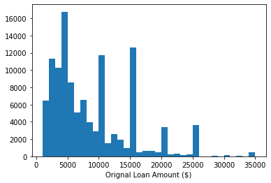

```python
# Look at distribution of the LoanOriginalAmount
amount_bins = np.arange(df.LoanOriginalAmount.min(), df.LoanOriginalAmount.max()+1e3, 1e3)

plt.hist(data=df, x='LoanOriginalAmount', bins=amount_bins);
plt.xlabel('Orignal Loan Amount ($)');
```

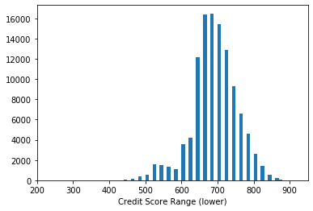

```python
# Look at CreditScoreRange distributions
lower_bins = np.arange(df.CreditScoreRangeLower.min(), df.CreditScoreRangeLower.max()+10, 10)

plt.hist(data=df, x='CreditScoreRangeLower', bins=lower_bins);
plt.xlim(200,950);
plt.xlabel('Credit Score Range (lower)');
```

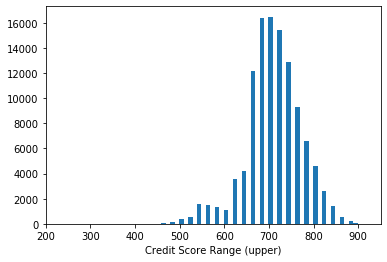

```python
# Look at CreditScoreRange distributions
upper_bins = np.arange(df.CreditScoreRangeUpper.min(), df.CreditScoreRangeUpper.max()+10, 10)

plt.hist(data=df, x='CreditScoreRangeUpper', bins=upper_bins);
plt.xlim(200,950);
plt.xlabel('Credit Score Range (upper)');
```

> Both of the CreditScoreRange have a similar distribution of the scores. Credit scores (FICO) usually range from 250-900, so the x-axis was limited to those ranges to better show the distribution. Most people in the dataset had a score around the 700 value, with few having a score above 800 or below 600.

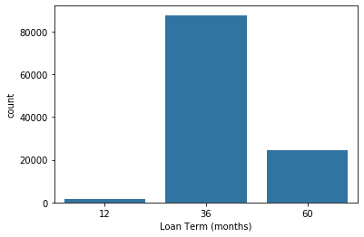

```python
# Look at the counts of each loan Term
sb.countplot(data=df, x='Term', color=base_color);
plt.xlabel('Loan Term (months)');
```

> The vast mojority of loans were given out for a term of 36 months. There were significantly less loans for 60 month terms, and almost none for 12 month terms. It will be interesting to see how this affected the interest rates.

## Bivariate Exploration

> I want to see how the different categoorical and numeric features relate to the interest rate columns.

```python
numeric_vars = ['Term',
                'BorrowerAPR',
                'BorrowerRate',
                'ProsperRating (numeric)',
                'ProsperScore',
                'CreditScoreRangeLower',
                'CreditScoreRangeUpper',
                'DebtToIncomeRatio',
                'LoanOriginalAmount']

categorical_vars = ['Term', 'CreditGrade', 'ProsperRating (Alpha)']
```

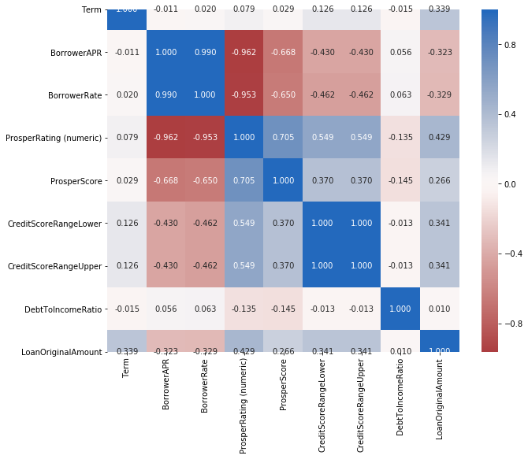

```python
# correlation plot of numeric variables
plt.figure(figsize = [10, 8])
sb.heatmap(df[numeric_vars].corr(), annot = True, fmt = '.3f',
           cmap = 'vlag_r', center = 0)
# plt.xticks(rotation=90);
plt.show()
```

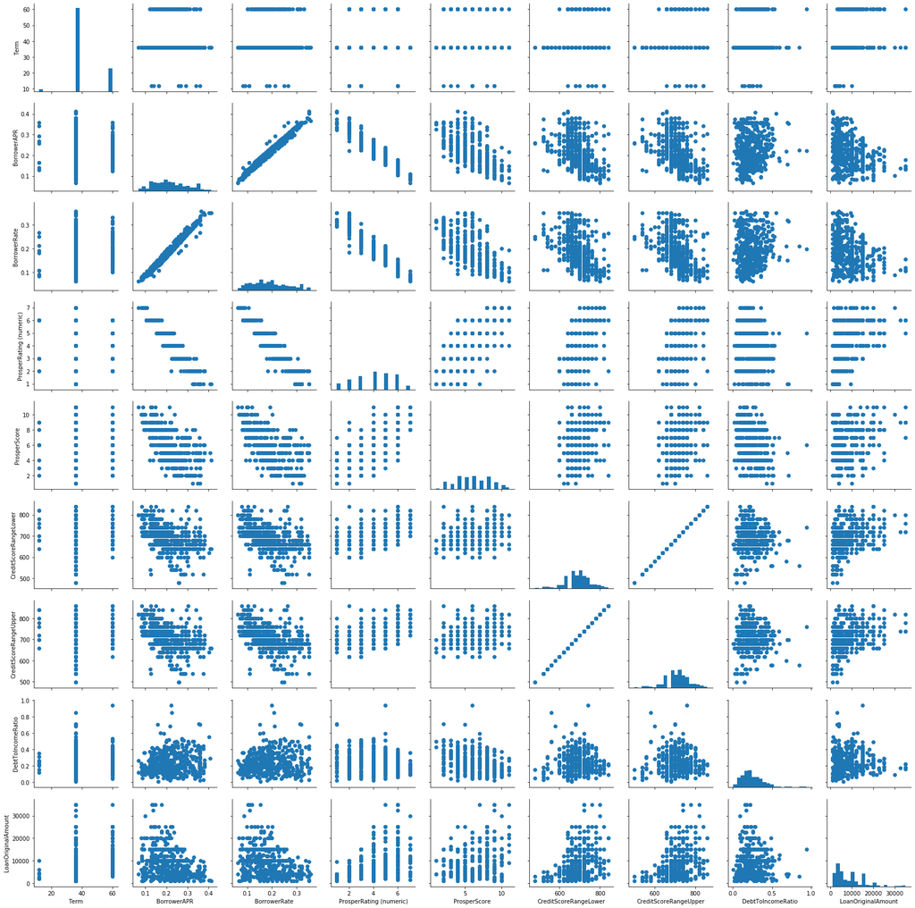

```python
# Look at a PairGrid of the numeric variables
# using a sample of the whole dataset to speed it up
sample = np.random.choice(df.shape[0], 500, replace=False)
loan_samp = df.loc[sample,:]

g = sb.PairGrid(data=loan_samp, vars=numeric_vars)
g = g.map_diag(plt.hist, bins=20);
g.map_offdiag(plt.scatter);
```

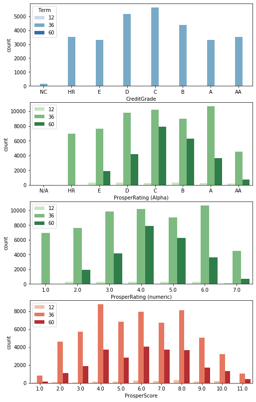

```python
# Look at relationship between Term and the CreditGrade/ProsperRating(s) and ProsperScore
plt.figure(figsize=[8,14])

plt.subplot(4,1,1)
sb.countplot(data=df, x='CreditGrade', hue='Term', palette='Blues');
ax.legend(loc=2);

ax = plt.subplot(4,1,2)
sb.countplot(data=df, x='ProsperRating (Alpha)', hue='Term', palette='Greens');
ax.legend(loc=2);

ax = plt.subplot(4,1,3)
sb.countplot(data=df, x='ProsperRating (numeric)', hue='Term', palette='Greens');
ax.legend(loc=2);

ax = plt.subplot(4,1,4)
sb.countplot(data=df, x='ProsperScore', hue='Term', palette='Reds');
ax.legend(loc=2);
```

> The limited number of loans before July 2009 have no 12 or 60 month terms. But when looking at data after July 2009 we see that 60 month term loans were quite popular with those with a a ProsperRating of C and B. As seen before 36 month term loans are the most popular across all credit risk groups.

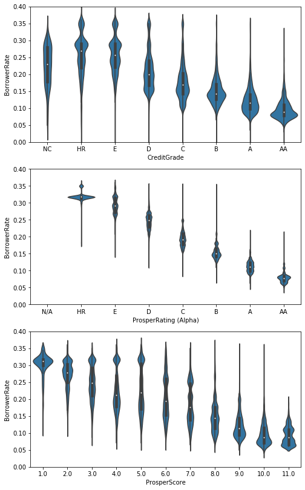

```python
plt.figure(figsize=[8,14])
plt.subplot(3,1,1)
sb.violinplot(data=df, x='CreditGrade', y='BorrowerRate', color=base_color);
plt.ylim((0,0.4));

plt.subplot(3,1,2)
sb.violinplot(data=df, x='ProsperRating (Alpha)', y='BorrowerRate', color=base_color);
plt.ylim((0,0.4));

plt.subplot(3,1,3)
sb.violinplot(data=df, x='ProsperScore', y='BorrowerRate', color=base_color);
plt.ylim((0,0.4));
```

> Looking at the violin plots for the distribution of the different credit risks annd the BorrowerRate is that there is a negative correlation between having a higher (better) score and a lower interest rate. This is once again most pronouced in the results for the ProsperRating (Alpha) variable where the decline is steeper. With the ProsperScore there is still a decilne, but the distribution of the BorrowerRate is more distributed and the IQR is genrally larger for each rating.

### Talk about some of the relationships you observed in this part of the investigation. How did the feature(s) of interest vary with other features in the dataset?

> Yes. Some of the credit risk variables seemed to be related to the interest rate of the loans. This was most pronounced with the ProsperRating (Alpha) data, but was evident in the other to a lesser extent. The results here appear reasonable, people with a higher (better) credit risk score will pay a lower interest rate.

### Did you observe any interesting relationships between the other features (not the main feature(s) of interest)?

> I was surprised how the DebtToIncomeRatio had no meaningfull correlation to the interest rate columns. The other feautres/columns were closer to the expectation. I did not explore all the features in the dataset because there are too many to include in this analysis.

## Multivariate Exploration

> I want to see why the ProsperScore is not very well correlated with the BorrowerRate based on the results I sawn in the bivariate exploration.

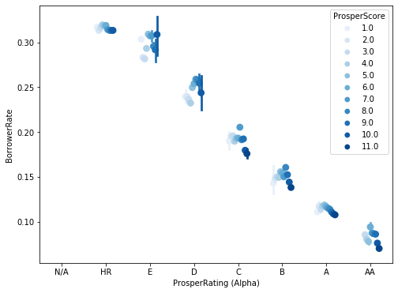

```python
# Create a pointplot to show how the ProsperScore is distributed acorss the different credit risk scores
# in relation to the BorrowerRate
fig = plt.figure(figsize=[8,6])

ax = sb.pointplot(data=df, x='ProsperRating (Alpha)', y='BorrowerRate', hue='ProsperScore',
                  dodge=0.4, linestyles='', palette='Blues');
```

> This seems to suggest that the ProsperScore is using different criteria than the other credit risk scores in the dataset. Higher values of ProsperScores are distributed across all of the different levels of the ProsperRating. Since ProsperRating is highly correlated to the interest rate features and the ProsperScore is distributed across all the ProsperRating(s) levels it's correlation to the BorrowerRate is deacreased. This answers a question I had previously, but creates one for a future analysis; how is the ProsperScore generated, what features/columns are used for it?

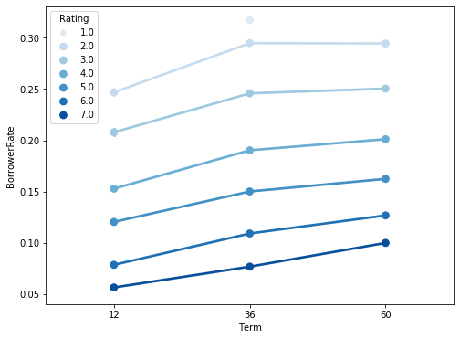

```python
# Create a pointplot to show how the BorrowerRate changes for different loan Terms
# when split up by ProsperRating
fig = plt.figure(figsize=[8,6])

ax = sb.pointplot(data=df, x='Term', y='BorrowerRate', hue='ProsperRating (numeric)',
                   palette='Blues');
plt.legend(loc=2, title='Rating');
```

### Talk about some of the relationships you observed in this part of the investigation. Were there features that strengthened each other in terms of looking at your feature(s) of interest?

> When looking at the ProsperRating (Alpha) and the ProsperScore as it relates to the BorrowerRate I was able to see an explanation for why the ProsperScore wasn't as highly correlated to the BorrowerRate. It unlike the other credit risk features must use different criteria in coming up with it's value.

### Were there any interesting or surprising interactions between features?

> I was surprised to see that the BorrowerRate increases for longer Term loans when split up by ProsperRating (numeric). The opposite relationship would be expected as longer term loans generally carry a lower risk profile and have a longer time to accrue interest.